# Project: Investigation of a Movie Dataset to find out the effect of capital invested in the movie industry.

- Introduction
- Data Wrangling
- Exploratory Data Analysis
- Conclusions

## Introduction

> In this project I'll be working with the tmdb-movie dataset which contains the details of budget for each movie, given their revenue, directors, production company id, and some other fields to help the viewer understand the data provided.

> **Questions**
> - What are the top 10 movies based on budget allocation?
> - Did these top 10 movies make the top 10 movies based on revenue?
> - Did these movies get a high vote average?

```python
# Imported packages which I will be using in this project

import pandas as pd
import numpy as np
import seaborn as sns
import matplotlib.pyplot as plt
% matplotlib inline

#  % sign (magic word) used so that the visualizations are plotted
#  inline with the notebook.
```

## Data Wrangling

### General Properties

```python
# Load your data and print out a few lines. Perform operations to inspect data
#   types and look for instances of missing or possibly errant data.
movies_df = pd.read_csv('tmdb-movies.csv') # Loads the tmdb-movies csv file
movies_df.head()  #reads few lines of the loaded file
```

|  | id | imdb_id | popularity | budget | revenue | original_title | cast | homepage | director | tagline | ... | overview | runtime | genres | production_companies | release_date | vote_count | vote_average | release_year | budget_adj | revenue_adj |
| --- | --- | --- | --- | --- | --- | --- | --- | --- | --- | --- | --- | --- | --- | --- | --- | --- | --- | --- | --- | --- | --- |
| 0 | 135397 | tt0369610 | 32.985763 | 150000000 | 1513528810 | Jurassic World | Chris Pratt\|Bryce Dallas Howard\|Irrfan Khan\|Vi... | http://www.jurassicworld.com/ | Colin Trevorrow | The park is open. | ... | Twenty-two years after the events of Jurassic ... | 124 | Action\|Adventure\|Science Fiction\|Thriller | Universal Studios\|Amblin Entertainment\|Legenda... | 6/9/15 | 5562 | 6.5 | 2015 | 1.379999e+08 | 1.392446e+09 |
| 1 | 76341 | tt1392190 | 28.419936 | 150000000 | 378436354 | Mad Max: Fury Road | Tom Hardy\|Charlize Theron\|Hugh Keays-Byrne\|Nic... | http://www.madmaxmovie.com/ | George Miller | What a Lovely Day. | ... | An apocalyptic story set in the furthest reach... | 120 | Action\|Adventure\|Science Fiction\|Thriller | Village Roadshow Pictures\|Kennedy Miller Produ... | 5/13/15 | 6185 | 7.1 | 2015 | 1.379999e+08 | 3.481613e+08 |
| 2 | 262500 | tt2908446 | 13.112507 | 110000000 | 295238201 | Insurgent | Shailene Woodley\|Theo James\|Kate Winslet\|Ansel... | http://www.thedivergentseries.movie/#insurgent | Robert Schwentke | One Choice Can Destroy You | ... | Beatrice Prior must confront her inner demons ... | 119 | Adventure\|Science Fiction\|Thriller | Summit Entertainment\|Mandeville Films\|Red Wago... | 3/18/15 | 2480 | 6.3 | 2015 | 1.012000e+08 | 2.716190e+08 |
| 3 | 140607 | tt2488496 | 11.173104 | 200000000 | 2068178225 | Star Wars: The Force Awakens | Harrison Ford\|Mark Hamill\|Carrie Fisher\|Adam D... | http://www.starwars.com/films/star-wars-episod... | J.J. Abrams | Every generation has a story. | ... | Thirty years after defeating the Galactic Empi... | 136 | Action\|Adventure\|Science Fiction\|Fantasy | Lucasfilm\|Truenorth Productions\|Bad Robot | 12/15/15 | 5292 | 7.5 | 2015 | 1.839999e+08 | 1.902723e+09 |
| 4 | 168259 | tt2820852 | 9.335014 | 190000000 | 1506249360 | Furious 7 | Vin Diesel\|Paul Walker\|Jason Statham\|Michelle ... | http://www.furious7.com/ | James Wan | Vengeance Hits Home | ... | Deckard Shaw seeks revenge against Dominic Tor... | 137 | Action\|Crime\|Thriller | Universal Pictures\|Original Film\|Media Rights ... | 4/1/15 | 2947 | 7.3 | 2015 | 1.747999e+08 | 1.385749e+09 |

5 rows × 21 columns

### Assessing structure of the data frame

> The first thing I did in assessing the data fram was to get a concise summary of the tmdb-movies using the df.info() function so it can help me understand the data I will be analysing.

### Findings

- There are 10,866 entries(rows) starting from 0 to 10865 index
- There are 21 columns in total
- Data types from each column present include floats(4), integers or in (6) and object or strings (11)

```python
movies_df.info()  # Prints a concise summary of a DataFrame.
```

```
<class 'pandas.core.frame.DataFrame'>
RangeIndex: 10866 entries, 0 to 10865
Data columns (total 21 columns):
id                      10866 non-null int64
imdb_id                 10856 non-null object
popularity              10866 non-null float64
budget                  10866 non-null int64
revenue                 10866 non-null int64
original_title          10866 non-null object
cast                    10790 non-null object
homepage                2936 non-null object
director                10822 non-null object
tagline                 8042 non-null object
keywords                9373 non-null object
overview                10862 non-null object
runtime                 10866 non-null int64
genres                  10843 non-null object
production_companies    9836 non-null object
release_date            10866 non-null object
vote_count              10866 non-null int64
vote_average            10866 non-null float64
release_year            10866 non-null int64
budget_adj              10866 non-null float64
revenue_adj             10866 non-null float64
dtypes: float64(4), int64(6), object(11)
memory usage: 1.7+ MB
```

```python
movies_df.shape  # Returns a tuple representing the dimensionality of the tmdb-movies DataFrame.
```

```
(10866, 21)
```

The df.shape function was used as confirmation for the df.info() function.

I also noticed that some values did not refelect the total number of enteries. Most were string(object) data types which might mean that not all data entered had all fields entered for instance, homepage, production_companies, overview, genre, keywords, tagline, director, cast and imdb_id.

#### Descriptive statistics

> Since I will be looking at budget, revenue and vote_average as it relates to original_title of the movies, I will talk about these columns and the findings.

#### Findings:

```python
movies_df.describe() # Prints a concise summary of a DataFrame.
```

|  | id | popularity | budget | revenue | runtime | vote_count | vote_average | release_year | budget_adj | revenue_adj |
| --- | --- | --- | --- | --- | --- | --- | --- | --- | --- | --- |
| count | 10866.000000 | 10866.000000 | 1.086600e+04 | 1.086600e+04 | 10866.000000 | 10866.000000 | 10866.000000 | 10866.000000 | 1.086600e+04 | 1.086600e+04 |
| mean | 66064.177434 | 0.646441 | 1.462570e+07 | 3.982332e+07 | 102.070863 | 217.389748 | 5.974922 | 2001.322658 | 1.755104e+07 | 5.136436e+07 |
| std | 92130.136561 | 1.000185 | 3.091321e+07 | 1.170035e+08 | 31.381405 | 575.619058 | 0.935142 | 12.812941 | 3.430616e+07 | 1.446325e+08 |
| min | 5.000000 | 0.000065 | 0.000000e+00 | 0.000000e+00 | 0.000000 | 10.000000 | 1.500000 | 1960.000000 | 0.000000e+00 | 0.000000e+00 |
| 25% | 10596.250000 | 0.207583 | 0.000000e+00 | 0.000000e+00 | 90.000000 | 17.000000 | 5.400000 | 1995.000000 | 0.000000e+00 | 0.000000e+00 |
| 50% | 20669.000000 | 0.383856 | 0.000000e+00 | 0.000000e+00 | 99.000000 | 38.000000 | 6.000000 | 2006.000000 | 0.000000e+00 | 0.000000e+00 |
| 75% | 75610.000000 | 0.713817 | 1.500000e+07 | 2.400000e+07 | 111.000000 | 145.750000 | 6.600000 | 2011.000000 | 2.085325e+07 | 3.369710e+07 |
| max | 417859.000000 | 32.985763 | 4.250000e+08 | 2.781506e+09 | 900.000000 | 9767.000000 | 9.200000 | 2015.000000 | 4.250000e+08 | 2.827124e+09 |

#### Duplicate entry:

Only 1 was after summing the movies_df.duplicated() function

```python
sum(movies_df.duplicated()) # Sums all boolean Series denoting duplicate rows as an integer
```

```
1
```

### Cleaning the tmdb-movies data set

#### Step 1

After viewing the summarry of data with .info(), some values were not complete so I used the .fillna() to fill in the missing values with the mean and put them inplace of the former value. Viewed the summary of the file and it was the same meaning that these might be string and were not inserted while creating the csv file.

#### Step 2

I also viewed the entries for budget to see those with zero so I can remove them because if there are zeroes in my data it might create a big difference in results because of the spread of values.

After I removed the zero values, I viewed the data to see if there was any and there wasn't any.

```python
movies_df.fillna(movies_df.mean(), inplace = True) # Fills NA/NaN values using the mean inplace of those missing values
movies_df.info()                                   # reads summary of the loaded file
```

```
<class 'pandas.core.frame.DataFrame'>
RangeIndex: 10866 entries, 0 to 10865
Data columns (total 21 columns):
id                      10866 non-null int64
imdb_id                 10856 non-null object
popularity              10866 non-null float64
budget                  10866 non-null int64
revenue                 10866 non-null int64
original_title          10866 non-null object
cast                    10790 non-null object
homepage                2936 non-null object
director                10822 non-null object
tagline                 8042 non-null object
keywords                9373 non-null object
overview                10862 non-null object
runtime                 10866 non-null int64
genres                  10843 non-null object
production_companies    9836 non-null object
release_date            10866 non-null object
vote_count              10866 non-null int64
vote_average            10866 non-null float64
release_year            10866 non-null int64
budget_adj              10866 non-null float64
revenue_adj             10866 non-null float64
dtypes: float64(4), int64(6), object(11)
memory usage: 1.7+ MB
```

```python
zero_budget = movies_df.query('budget == 0')  # Checks fields in the budget column that are equal to zero
zero_budget.head(40)     #Prints 40 entries (rows) with zero as an entry for budget
```

|  | id | imdb_id | popularity | budget | revenue | original_title | cast | homepage | director | tagline | ... | overview | runtime | genres | production_companies | release_date | vote_count | vote_average | release_year | budget_adj | revenue_adj |
| --- | --- | --- | --- | --- | --- | --- | --- | --- | --- | --- | --- | --- | --- | --- | --- | --- | --- | --- | --- | --- | --- |
| 30 | 280996 | tt3168230 | 3.927333 | 0 | 29355203 | Mr. Holmes | Ian McKellen\|Milo Parker\|Laura Linney\|Hattie M... | http://www.mrholmesfilm.com/ | Bill Condon | The man behind the myth | ... | The story is set in 1947, following a long-ret... | 103 | Mystery\|Drama | BBC Films\|See-Saw Films\|FilmNation Entertainme... | 6/19/15 | 425 | 6.4 | 2015 | 0.0 | 2.700677e+07 |
| 36 | 339527 | tt1291570 | 3.358321 | 0 | 22354572 | Solace | Abbie Cornish\|Jeffrey Dean Morgan\|Colin Farrel... | NaN | Afonso Poyart | A serial killer who can see your future, a psy... | ... | A psychic doctor, John Clancy, works with an F... | 101 | Crime\|Drama\|Mystery | Eden Rock Media\|FilmNation Entertainment\|Flynn... | 9/3/15 | 474 | 6.2 | 2015 | 0.0 | 2.056620e+07 |
| 72 | 284289 | tt2911668 | 2.272044 | 0 | 45895 | Beyond the Reach | Michael Douglas\|Jeremy Irvine\|Hanna Mangan Law... | NaN | Jean-Baptiste Léonetti | NaN | ... | A high-rolling corporate shark and his impover... | 95 | Thriller | Furthur Films | 4/17/15 | 81 | 5.5 | 2015 | 0.0 | 4.222338e+04 |
| 74 | 347096 | tt3478232 | 2.165433 | 0 | 0 | Mythica: The Darkspore | Melanie Stone\|Kevin Sorbo\|Adam Johnson\|Jake St... | http://www.mythicamovie.com/#!blank/wufvh | Anne K. Black | NaN | ... | When Teela’s sister is murdered and a powerf... | 108 | Action\|Adventure\|Fantasy | Arrowstorm Entertainment | 6/24/15 | 27 | 5.1 | 2015 | 0.0 | 0.000000e+00 |
| 75 | 308369 | tt2582496 | 2.141506 | 0 | 0 | Me and Earl and the Dying Girl | Thomas Mann\|RJ Cyler\|Olivia Cooke\|Connie Britt... | http://www.foxsearchlight.com/meandearlandthed... | Alfonso Gomez-Rejon | A Little Friendship Never Killed Anyone. | ... | Greg is coasting through senior year of high s... | 105 | Comedy\|Drama | Indian Paintbrush | 6/12/15 | 569 | 7.7 | 2015 | 0.0 | 0.000000e+00 |
| 88 | 301875 | tt3289728 | 1.959765 | 0 | 2000000 | Equals | Kristen Stewart\|Nicholas Hoult\|Guy Pearce\|Jack... | http://equals-the-movie.com/ | Drake Doremus | Find your equal. | ... | A futuristic love story set in a world where e... | 101 | Drama\|Romance\|Science Fiction | Scott Free Productions\|Infinite Frameworks Stu... | 9/4/15 | 135 | 5.6 | 2015 | 0.0 | 1.839999e+06 |
| 92 | 370687 | tt3608646 | 1.876037 | 0 | 0 | Mythica: The Necromancer | Melanie Stone\|Adam Johnson\|Kevin Sorbo\|Nicola ... | http://www.mythicamovie.com/#!blank/y9ake | A. Todd Smith | NaN | ... | Mallister takes Thane prisoner and forces Mare... | 0 | Fantasy\|Action\|Adventure | Arrowstorm Entertainment\|Camera 40 Productions... | 12/19/15 | 11 | 5.4 | 2015 | 0.0 | 0.000000e+00 |
| 95 | 258509 | tt2974918 | 1.841779 | 0 | 233755553 | Alvin and the Chipmunks: The Road Chip | Jason Lee\|Justin Long\|Bella Thorne\|Matthew Gra... | http://www.foxmovies.com/movies/alvin-and-the-... | Walt Becker | Fast & furry-ous | ... | Through a series of misunderstandings, Alvin, ... | 92 | Adventure\|Animation\|Comedy\|Family | Regency Enterprises\|Fox 2000 Pictures\|Sunswept... | 12/17/15 | 278 | 5.7 | 2015 | 0.0 | 2.150550e+08 |
| 100 | 326359 | tt4007502 | 1.724712 | 0 | 0 | Frozen Fever | Kristen Bell\|Idina Menzel\|Jonathan Groff\|Josh ... | NaN | Chris Buck\|Jennifer Lee | NaN | ... | On Anna's birthday, Elsa and Kristoff are dete... | 8 | Adventure\|Animation\|Family | Walt Disney Pictures\|Walt Disney Animation Stu... | 3/9/15 | 475 | 7.0 | 2015 | 0.0 | 0.000000e+00 |
| 101 | 254302 | tt0462335 | 1.661789 | 0 | 0 | High-Rise | Tom Hiddleston\|Sienna Miller\|Jeremy Irons\|Luke... | NaN | Ben Wheatley | Leave the real world behind | ... | Dr. Robert Laing is the newest resident of a l... | 119 | Action\|Drama\|Science Fiction | Ingenious Media\|HanWay Films\|Scope Pictures\|Re... | 9/26/15 | 161 | 5.4 | 2015 | 0.0 | 0.000000e+00 |
| 103 | 292040 | tt3321300 | 1.646664 | 0 | 0 | Spooks: The Greater Good | Peter Firth\|Kit Harington\|Jennifer Ehle\|Lara P... | http://www.shinepictures.co.uk/films/9/spooks-... | Bharat Nalluri | NaN | ... | During a handover to the head of counter-terro... | 104 | Thriller\|Action | BBC Films\|Isle of Man Film\|Shine Pictures\|Kudo... | 4/11/15 | 114 | 5.6 | 2015 | 0.0 | 0.000000e+00 |
| 116 | 297291 | tt3086386 | 1.380320 | 0 | 0 | The Scorpion King: The Lost Throne | Victor Webster\|Ellen Hollman\|Barry Bostwick\|Wi... | NaN | Mike Elliott | Action Adventure | ... | When he is betrayed by a trusted friend, Matha... | 105 | Action\|Fantasy\|Adventure | Universal Pictures | 1/9/15 | 22 | 4.5 | 2015 | 0.0 | 0.000000e+00 |
| 119 | 86828 | tt1727770 | 1.360827 | 0 | 5189646 | Absolutely Anything | Simon Pegg\|Kate Beckinsale\|Rob Riggle\|Sanjeev ... | NaN | Terry Jones | Great power. Total irresponsibility. | ... | Eccentric aliens give a man the power to do an... | 85 | Comedy\|Science Fiction | Premiere Picture\|Bill and Ben Productions\|GFM ... | 6/26/15 | 199 | 5.8 | 2015 | 0.0 | 4.774472e+06 |
| 122 | 277355 | tt1945084 | 1.342839 | 0 | 0 | Everly | Salma Hayek\|Hiroyuki Watanabe\|Jennifer Blanc\|T... | NaN | Joe Lynch | Enter if you dare. | ... | After she betrays a powerful mob boss, a woman... | 90 | Thriller\|Action | Crime Scene Pictures\|Radius-TWC\|Anonymous Cont... | 1/23/15 | 169 | 5.1 | 2015 | 0.0 | 0.000000e+00 |
| 125 | 223485 | tt3205376 | 1.329702 | 0 | 229094 | Slow West | Michael Fassbender\|Kodi Smit-McPhee\|Ben Mendel... | NaN | John Maclean | Wanted Dead or Dead | ... | In the Old West, a 17-year-old Scottish boy te... | 84 | Romance\|Thriller\|Western | The New Zealand Film Commission\|Film4\|See Saw ... | 4/16/15 | 229 | 6.6 | 2015 | 0.0 | 2.107664e+05 |
| 128 | 309245 | tt2872462 | 1.293140 | 0 | 2500431 | Mistress America | Greta Gerwig\|Lola Kirke\|Charlie Gillette\|Dean ... | NaN | Noah Baumbach | From Strangers to Sisters. | ... | Tracy, a lonely college freshman in New York, ... | 84 | Comedy | RT Features | 8/14/15 | 132 | 6.4 | 2015 | 0.0 | 2.300396e+06 |
| 130 | 245706 | tt2273657 | 1.284541 | 0 | 4719695 | True Story | Jonah Hill\|James Franco\|Felicity Jones\|Maria D... | NaN | Rupert Goold | Some mysteries are beyond belief. | ... | A drama centered around the relationship betwe... | 100 | Crime\|Drama\|Mystery | Plan B Entertainment\|Regency Enterprises\|New R... | 4/17/15 | 354 | 6.0 | 2015 | 0.0 | 4.342117e+06 |
| 132 | 263109 | tt2872750 | 1.253580 | 0 | 59700000 | Shaun the Sheep Movie | Justin Fletcher\|Omid Djalili\|Richard Webber\|Ka... | http://www.shaunthesheep.com/ | Mark Burton\|Richard Starzack | Moving on to Pastures New. | ... | When Shaun decides to take the day off and hav... | 85 | Family\|Animation\|Comedy\|Adventure | Aardman Animations\|Studio Canal\|Anton Capital ... | 2/5/15 | 340 | 6.9 | 2015 | 0.0 | 5.492398e+07 |
| 134 | 321751 | tt3577624 | 1.245224 | 0 | 1702433 | A Perfect Day | Olga Kurylenko\|Benicio del Toro\|Tim Robbins\|MÃ... | NaN | Fernando León de Aranoa | NaN | ... | Film about a group of aid workers trying to re... | 106 | Comedy\|Drama | Reposado Producciones\|Televisión Española (T... | 8/28/15 | 102 | 6.3 | 2015 | 0.0 | 1.566238e+06 |
| 139 | 193687 | tt1598642 | 1.161812 | 0 | 118483 | Z for Zachariah | Margot Robbie\|Chiwetel Ejiofor\|Chris Pine | http://www.facebook.com/ZforZachariah | Craig Zobel | After the end of the world she thought she was... | ... | In the wake of a nuclear war, a young woman su... | 97 | Drama\|Science Fiction\|Thriller | Palomar Pictures\|Lucky Hat Entertainment\|Silve... | 8/13/15 | 181 | 5.5 | 2015 | 0.0 | 1.090043e+05 |
| 140 | 300803 | tt3829170 | 1.144808 | 0 | 0 | Dragonheart 3: The Sorcerer's Curse | Julian Morris\|Tamzin Merchant\|Jassa Ahluwalia\|... | NaN | Colin Teague | NaN | ... | When aspiring knight Gareth goes in search of ... | 97 | Action\|Adventure\|Fantasy | Raffaella Productions | 2/24/15 | 59 | 4.5 | 2015 | 0.0 | 0.000000e+00 |
| 143 | 378373 | tt3532278 | 1.128081 | 0 | 0 | Brothers of the Wind | Manuel Camacho\|Jean Reno\|Tobias Moretti\|Eva Kuen | http://www.terramater.at/cinema/brothers-of-th... | Gerado Olivares\|Otmar Penker | Sometimes a friendship sets you free | ... | The way of the eagle is to raise two chicks. T... | 98 | Adventure\|Drama\|Family | Terra Mater Factual Studios | 12/24/15 | 11 | 7.5 | 2015 | 0.0 | 0.000000e+00 |
| 146 | 241257 | tt3319920 | 1.065888 | 0 | 17671101 | Regression | Ethan Hawke\|Emma Watson\|Aaron Ashmore\|Devon Bo... | NaN | Alejandro Amenábar | Fear always finds its victim | ... | Minnesota, 1990. Detective Bruce Kenner (Ethan... | 106 | Horror\|Mystery\|Thriller | The Weinstein Company\|Himenóptero\|First Gener... | 10/1/15 | 310 | 5.2 | 2015 | 0.0 | 1.625741e+07 |
| 147 | 245698 | tt1596345 | 1.063055 | 0 | 0 | Pawn Sacrifice | Tobey Maguire\|Lily Rabe\|Peter Sarsgaard\|Liev S... | NaN | Edward Zwick | On the board he fought the Cold War. In his mi... | ... | American chess champion Bobby Fischer prepares... | 114 | Drama | Material Pictures\|MICA Entertainment\|PalmStar ... | 9/16/15 | 148 | 6.6 | 2015 | 0.0 | 0.000000e+00 |
| 148 | 353326 | tt0787524 | 1.046518 | 0 | 11472454 | The Man Who Knew Infinity | Jeremy Irons\|Dev Patel\|Toby Jones\|Stephen Fry\|... | http://www.ifcfilms.com/films/the-man-who-knew... | Matt Brown | What does it take to prove the impossible? | ... | Growing up poor in Madras, India, Srinivasa Ra... | 108 | Drama | Animus Films\|Edward R. Pressman Film\|Kreo Film... | 9/17/15 | 104 | 7.1 | 2015 | 0.0 | 1.055465e+07 |
| 151 | 290637 | tt3733778 | 1.036825 | 0 | 0 | Pay the Ghost | Nicolas Cage\|Sarah Wayne Callies\|Veronica Ferr... | NaN | Uli Edel | Evil walks among us. | ... | One year after his young son disappeared durin... | 94 | Horror\|Thriller | Voltage Films\|Midnight Kitchen Productions | 9/16/15 | 114 | 5.3 | 2015 | 0.0 | 0.000000e+00 |
| 152 | 244458 | tt1567437 | 1.027620 | 0 | 0 | The Voices | Ryan Reynolds\|Gemma Arterton\|Anna Kendrick\|Jac... | NaN | Marjane Satrapi | Hearing voices can be murder. | ... | A mentally unhinged factory worker must decide... | 101 | Horror\|Thriller\|Comedy\|Crime | Studio Babelsberg\|Mandalay Vision\|1984 Private... | 2/6/15 | 371 | 6.0 | 2015 | 0.0 | 0.000000e+00 |
| 153 | 308504 | tt2493486 | 1.021441 | 0 | 3643591 | Last Knights | Clive Owen\|Morgan Freeman\|Aksel Hennie\|Shohreh... | NaN | Kazuaki Kiriya | NaN | ... | When an evil emperor executes their leader, hi... | 115 | Action\|Adventure | Czech Anglo Productions\|Luka Productions | 4/3/15 | 237 | 6.3 | 2015 | 0.0 | 3.352102e+06 |
| 158 | 290762 | tt2245003 | 0.953647 | 0 | 0 | Miss You Already | Drew Barrymore\|Toni Collette\|Dominic Cooper\|Ja... | NaN | Catherine Hardwicke | When life falls apart, friends keep it together | ... | The friendship between two life-long girlfrien... | 112 | Comedy\|Drama\|Romance | S Films\|New Sparta Films | 9/12/15 | 139 | 7.2 | 2015 | 0.0 | 0.000000e+00 |
| 161 | 324807 | tt2056771 | 0.938432 | 0 | 1936524 | A Bigger Splash | Tilda Swinton\|Matthias Schoenaerts\|Ralph Fienn... | NaN | Luca Guadagnino | NaN | ... | An American couple, Paul and Marianne, spend t... | 120 | Crime\|Drama\|Mystery\|Thriller | StudioCanal\|Ministero per i Beni e le AttivitÃ... | 11/26/15 | 69 | 5.8 | 2015 | 0.0 | 1.781601e+06 |
| 164 | 228968 | tt2917388 | 0.917040 | 0 | 0 | Kidnapping Mr. Heineken | Anthony Hopkins\|Jim Sturgess\|Sam Worthington\|R... | http://kidnappingmrheinekenmovie.com/ | Daniel Alfredson | It was the perfect crime until they got away w... | ... | The true story of the kidnapping of Freddy Hei... | 95 | Drama\|Action\|Crime\|Thriller | Umedia\|Informant Europe SPRL\|European Film Com... | 3/12/15 | 131 | 5.8 | 2015 | 0.0 | 0.000000e+00 |
| 166 | 237756 | tt2393845 | 0.906860 | 0 | 0 | Kill Me Three Times | Teresa Palmer\|Simon Pegg\|Luke Hemsworth\|Sulliv... | NaN | Kriv Stenders | Once is never enough. | ... | While on a seemingly routine job, a jaded hit ... | 90 | Comedy\|Thriller | Parabolic Pictures\|Stable Way Entertainment\|Ca... | 4/10/15 | 96 | 5.1 | 2015 | 0.0 | 0.000000e+00 |
| 169 | 311291 | tt3544082 | 0.894477 | 0 | 0 | 45 Years | Charlotte Rampling\|Tom Courtenay\|Dolly Wells\|G... | NaN | Andrew Haigh | NaN | ... | There is just one week until Kate Mercer's 45t... | 95 | Drama | The Bureau | 8/28/15 | 167 | 6.0 | 2015 | 0.0 | 0.000000e+00 |
| 171 | 248574 | tt1731701 | 0.880268 | 0 | 6075 | Barely Lethal | Hailee Steinfeld\|Sophie Turner\|Jessica Alba\|Sa... | NaN | Kyle Newman | Click. Clique. Bang. | ... | A 16-year-old international assassin yearning ... | 96 | Adventure\|Action\|Comedy | A24 | 4/30/15 | 215 | 5.5 | 2015 | 0.0 | 5.588998e+03 |
| 172 | 225728 | tt2884018 | 0.874641 | 0 | 13192457 | Macbeth | Michael Fassbender\|Marion Cotillard\|Paddy Cons... | http://www.macbeth-movie.com/ | Justin Kurzel | All hail Macbeth that shall be king | ... | Feature film adaptation of Shakespeare's Scott... | 113 | History\|Drama\|War | Studio Canal\|See-Saw Films\|Creative Scotland\|F... | 8/16/15 | 269 | 6.4 | 2015 | 0.0 | 1.213706e+07 |
| 173 | 326425 | tt4382872 | 0.872149 | 0 | 16775 | Extraction | Bruce Willis\|Gina Carano\|Kellan Lutz\|D. B. Swe... | http://lionsgatepremiere.com/extraction | Steven C. Miller | Vengeance runs in the family. | ... | A former CIA operative is kidnapped by a group... | 83 | Action\|Thriller | Emmett/Furla Films\|Oasis Films\|Aperture Entert... | 12/18/15 | 57 | 4.2 | 2015 | 0.0 | 1.543299e+04 |
| 174 | 342474 | tt3289712 | 0.861179 | 0 | 0 | Jenny's Wedding | Katherine Heigl\|Tom Wilkinson\|Alexis Bledel\|Gr... | https://www.facebook.com/jennysweddingmovie | Mary Agnes Donoghue | Family is worth fighting for. | ... | Jenny Farrell is getting married. But how will... | 94 | Comedy\|Drama | MM Productions\|Merced Media Partners\|PalmStar ... | 7/31/15 | 92 | 5.2 | 2015 | 0.0 | 0.000000e+00 |
| 175 | 277217 | tt3440298 | 0.848748 | 0 | 0 | Descendants | Booboo Stewart\|Dove Cameron\|Keegan Connor Trac... | NaN | Kenny Ortega | They're not bad. They're just born that way. | ... | A present-day idyllic kingdom where the benevo... | 112 | Music\|Action\|Adventure\|Comedy\|Family | Walt Disney Television | 7/31/15 | 262 | 6.7 | 2015 | 0.0 | 0.000000e+00 |
| 176 | 207936 | tt2338424 | 0.843174 | 0 | 0 | Tumbledown | Joe Manganiello\|Jason Sudeikis\|Blythe Danner\|R... | NaN | Sean Mewshaw | Turn the page. Start a new chapter. | ... | A young woman struggles to move on with her li... | 105 | Music\|Romance\|Comedy | Echo Films\|Bron Studios\|Hahnscape | 4/18/15 | 22 | 6.6 | 2015 | 0.0 | 0.000000e+00 |
| 177 | 250734 | tt2935476 | 0.842202 | 0 | 30229977 | Far from the Madding Crowd | Carey Mulligan\|Matthias Schoenaerts\|Michael Sh... | NaN | Thomas Vinterberg | NaN | ... | A beautiful young woman maintains relationship... | 119 | Romance\|Drama | Fox Searchlight Pictures\|DNA Films\|BBC Films | 5/1/15 | 220 | 6.9 | 2015 | 0.0 | 2.781157e+07 |

40 rows × 21 columns

```python
movies_df = movies_df[movies_df.budget != 0]   # Removes all rows with '0' values from the budject column
```

```python
movies_df[movies_df.budget==0].head()  # Prints out few rows
```

|  | id | imdb_id | popularity | budget | revenue | original_title | cast | homepage | director | tagline | ... | overview | runtime | genres | production_companies | release_date | vote_count | vote_average | release_year | budget_adj | revenue_adj |
| --- | --- | --- | --- | --- | --- | --- | --- | --- | --- | --- | --- | --- | --- | --- | --- | --- | --- | --- | --- | --- | --- |

0 rows × 21 columns

#### Step 3

Looking through the data I find out that there are columns which wouldn't be of value or interest in this investigation so I dropped (removd/deleted) them so I can focus on the part needed for analysis.

```python
movies_df.drop(['homepage', 'tagline', 'cast', 'overview', 'keywords', 'release_date'], axis = 1, inplace = True) # Removes the collums not needed for the analysis
movies_df.head()   # Prints out few rows
```

|  | id | imdb_id | popularity | budget | revenue | original_title | director | runtime | genres | production_companies | vote_count | vote_average | release_year | budget_adj | revenue_adj |
| --- | --- | --- | --- | --- | --- | --- | --- | --- | --- | --- | --- | --- | --- | --- | --- |
| 0 | 135397 | tt0369610 | 32.985763 | 150000000 | 1513528810 | Jurassic World | Colin Trevorrow | 124 | Action\|Adventure\|Science Fiction\|Thriller | Universal Studios\|Amblin Entertainment\|Legenda... | 5562 | 6.5 | 2015 | 1.379999e+08 | 1.392446e+09 |
| 1 | 76341 | tt1392190 | 28.419936 | 150000000 | 378436354 | Mad Max: Fury Road | George Miller | 120 | Action\|Adventure\|Science Fiction\|Thriller | Village Roadshow Pictures\|Kennedy Miller Produ... | 6185 | 7.1 | 2015 | 1.379999e+08 | 3.481613e+08 |
| 2 | 262500 | tt2908446 | 13.112507 | 110000000 | 295238201 | Insurgent | Robert Schwentke | 119 | Adventure\|Science Fiction\|Thriller | Summit Entertainment\|Mandeville Films\|Red Wago... | 2480 | 6.3 | 2015 | 1.012000e+08 | 2.716190e+08 |
| 3 | 140607 | tt2488496 | 11.173104 | 200000000 | 2068178225 | Star Wars: The Force Awakens | J.J. Abrams | 136 | Action\|Adventure\|Science Fiction\|Fantasy | Lucasfilm\|Truenorth Productions\|Bad Robot | 5292 | 7.5 | 2015 | 1.839999e+08 | 1.902723e+09 |
| 4 | 168259 | tt2820852 | 9.335014 | 190000000 | 1506249360 | Furious 7 | James Wan | 137 | Action\|Crime\|Thriller | Universal Pictures\|Original Film\|Media Rights ... | 2947 | 7.3 | 2015 | 1.747999e+08 | 1.385749e+09 |

#### Step 4

Since there was 1 duplicate entry, I used the drop duplicate remove it and put 1 of the entries in place of the duplicate dropped.

#### Step 5

I noticed there were missing values (NaN) mostly in the str (object) type values due to human error perhaps. To avoid complications in my analysis I dropped all missing values. Then I viewed the summary of the data set to see if my previous code worked well.

```python
movies_df.drop_duplicates(inplace = True)   # Removes dulpicate values
sum(movies_df.duplicated())
```

```
0
```

```python
movies_df.dropna(inplace = True)  #Removes all missing values from the data set
movies_df.info()
```

```
<class 'pandas.core.frame.DataFrame'>
Int64Index: 5029 entries, 0 to 10865
Data columns (total 15 columns):
id                      5029 non-null int64
imdb_id                 5029 non-null object
popularity              5029 non-null float64
budget                  5029 non-null int64
revenue                 5029 non-null int64
original_title          5029 non-null object
director                5029 non-null object
runtime                 5029 non-null int64
genres                  5029 non-null object
production_companies    5029 non-null object
vote_count              5029 non-null int64
vote_average            5029 non-null float64
release_year            5029 non-null int64
budget_adj              5029 non-null float64
revenue_adj             5029 non-null float64
dtypes: float64(4), int64(6), object(5)
memory usage: 628.6+ KB
```

#### Step 6

I used the .describe() function to view the descriptive statistics of the cleaned data and compared with what I had before.

- I assumed that a movie can cost 1 dollar that's why the minimum value in the budget column is 1. This new data closes the gap based on range.
- I also assumed that a movie can get 0 revenue so I left the minimum value for revenue at that. Although the ranges are spread.
- Since I am not using the runtime column I left the minimum value as it is at 0.

```python
movies_df.describe()  # reads summary of the loaded file
```

|  | id | popularity | budget | revenue | runtime | vote_count | vote_average | release_year | budget_adj | revenue_adj |
| --- | --- | --- | --- | --- | --- | --- | --- | --- | --- | --- |
| count | 5029.000000 | 5029.000000 | 5.029000e+03 | 5.029000e+03 | 5029.000000 | 5029.000000 | 5029.000000 | 5029.000000 | 5.029000e+03 | 5.029000e+03 |
| mean | 45122.333267 | 1.013331 | 3.144247e+07 | 8.245054e+07 | 107.463710 | 419.366673 | 6.044343 | 2001.133824 | 3.773174e+07 | 1.049541e+08 |
| std | 72640.288298 | 1.341348 | 3.919465e+07 | 1.611502e+08 | 22.492784 | 796.545696 | 0.868183 | 11.849552 | 4.219944e+07 | 1.979118e+08 |
| min | 5.000000 | 0.002514 | 1.000000e+00 | 0.000000e+00 | 0.000000 | 10.000000 | 1.500000 | 1960.000000 | 9.210911e-01 | 0.000000e+00 |
| 25% | 8619.000000 | 0.361298 | 6.100000e+06 | 3.561000e+03 | 94.000000 | 39.000000 | 5.500000 | 1995.000000 | 8.831996e+06 | 3.744992e+03 |
| 50% | 12526.000000 | 0.640933 | 1.800000e+07 | 2.296370e+07 | 103.000000 | 130.000000 | 6.100000 | 2004.000000 | 2.370705e+07 | 3.128737e+07 |
| 75% | 44571.000000 | 1.177428 | 4.000000e+07 | 9.291317e+07 | 117.000000 | 415.000000 | 6.600000 | 2010.000000 | 5.082002e+07 | 1.166571e+08 |
| max | 417859.000000 | 32.985763 | 4.250000e+08 | 2.781506e+09 | 540.000000 | 9767.000000 | 8.400000 | 2015.000000 | 4.250000e+08 | 2.827124e+09 |

## Exploratory Data Analysis

Before answering question one, I looked at individual variable and how they correspond to the data used for this investigation.

### Question 1 - Top 10 Movies based on budget alocation from 1960 to 2015

- 1. The Warriors Way - 425,000,000 dollars
- 1. Pirates of the Caribbean: On Stranger Tides - 380,000,000 dollars
- 1. Pirates of the Caribbean: At World's End - 300,000,000 dollars
- 1. Avengers: Age of Ultron - 280,000,000 dollars
- 1. Superman Returns - 270,000,000 dollars
- 1. John Carter - 260,000,000 dollars
- 1. Tangled - 260,000,000 dollars
- 1. Spider-Man 3 - 258,000,000 dollars
- 1. The Lone Ranger - 255,000,000 dollars
- 1. Harry Potter and the Deathly Hallows: Part 1 - 250,000,000 dollars

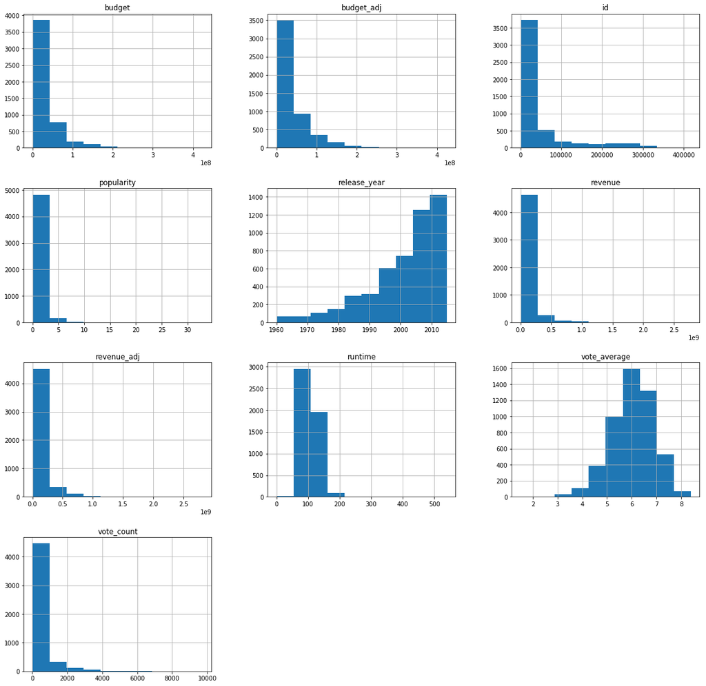

```python
movies_df.hist(figsize = (20,20));   # Makes a histogram of the DataFrame
```

```python
def compare_values(column):   # the function takes a column name (key) and produces a table grouped by original_title
    return movies_df.groupby('original_title').mean().nlargest(10, column)

compare_values('budget') # Produces a table showing the 10 Movies (original_title) from highest to lowest budget
```

| original_title | id | popularity | budget | revenue | runtime | vote_count | vote_average | release_year | budget_adj | revenue_adj |
| --- | --- | --- | --- | --- | --- | --- | --- | --- | --- | --- |
| The Warrior's Way | 46528.0 | 0.250540 | 425000000.0 | 1.108757e+07 | 100.0 | 74.0 | 6.4 | 2010.0 | 4.250000e+08 | 1.108757e+07 |
| Pirates of the Caribbean: On Stranger Tides | 1865.0 | 4.955130 | 380000000.0 | 1.021683e+09 | 136.0 | 3180.0 | 6.3 | 2011.0 | 3.683713e+08 | 9.904175e+08 |
| Pirates of the Caribbean: At World's End | 285.0 | 4.965391 | 300000000.0 | 9.610000e+08 | 169.0 | 2626.0 | 6.8 | 2007.0 | 3.155006e+08 | 1.010654e+09 |
| Avengers: Age of Ultron | 99861.0 | 5.944927 | 280000000.0 | 1.405036e+09 | 141.0 | 4304.0 | 7.4 | 2015.0 | 2.575999e+08 | 1.292632e+09 |
| Superman Returns | 1452.0 | 1.957331 | 270000000.0 | 3.910812e+08 | 154.0 | 834.0 | 5.3 | 2006.0 | 2.920507e+08 | 4.230205e+08 |
| John Carter | 49529.0 | 1.588457 | 260000000.0 | 2.841391e+08 | 132.0 | 1479.0 | 6.0 | 2012.0 | 2.469335e+08 | 2.698595e+08 |
| Tangled | 38757.0 | 2.865684 | 260000000.0 | 5.917949e+08 | 100.0 | 2019.0 | 7.3 | 2010.0 | 2.600000e+08 | 5.917949e+08 |
| Spider-Man 3 | 559.0 | 2.520912 | 258000000.0 | 8.908716e+08 | 139.0 | 2083.0 | 5.8 | 2007.0 | 2.713305e+08 | 9.369017e+08 |
| The Lone Ranger | 57201.0 | 1.214510 | 255000000.0 | 8.928991e+07 | 149.0 | 1607.0 | 6.0 | 2013.0 | 2.386885e+08 | 8.357833e+07 |
| Harry Potter and the Deathly Hallows: Part 1 | 12444.0 | 4.840588 | 250000000.0 | 9.543059e+08 | 146.0 | 3467.0 | 7.4 | 2010.0 | 2.500000e+08 | 9.543059e+08 |

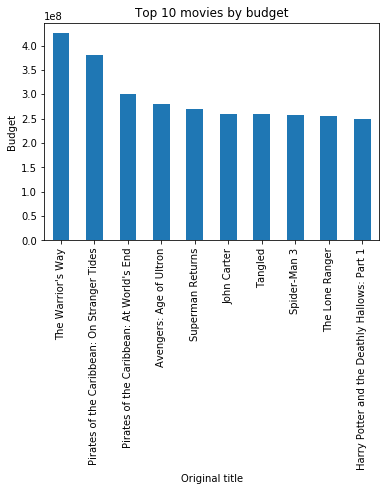

```python
movies_df.groupby('original_title').mean().budget.nlargest(10).plot(kind = 'bar');  # Plots a bar chart with original title on x axis and Budget on y axis

plt.ylabel('Budget')
plt.title('Top 10 movies by budget')
plt.xlabel('Original title')

plt.show()
```

### Question 2: Top 10 movies by revenue from 1960 to 2015

> We have seen the top movies based on budget, now let's see the top 10 movies based on revenue
- 1. Avatar - 2,781.506,000 dollars
- 1. Star Wars: The Force Awakens - 2,068,178,000 dollars
- 1. Jurassic World - 1,513,529, dollars
- 1. Furious 7 - 1,506,249,000 dollars
- 1. Avengers: Age of Ultron - 1,405,036,000 dollars
- 1. Harry Potter and the Deathly Hallows: Part 2 - 1,327,818,000 dollars
- 1. Frozen - 1,274,219,000 dollars
- 1. Iron Man 3 - 1,215,440,000 dollars
- 1. Minions - 1,156,731,000 dollars
- 1. Transformers: Dark of the Moon - 1,123,747,000 dollars

Between the top two movies, there is a significant difference in the revenue gain if we look at the table below we also find that the top two movies got a vote average score higher than the total average. Jurassic World and Furious 7 both released in 2015 have really similar revenue while the remaining values show a fine decent till number 10.

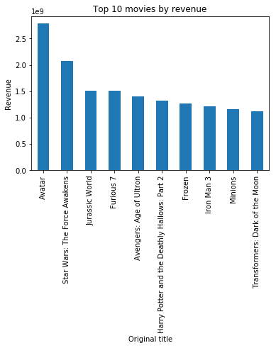

```python
# Continue to explore the data to address your additional research
#   questions. Add more headers as needed if you have more questions to
#   investigate.
movies_df.groupby('original_title').mean().revenue.nlargest(10).plot(kind = 'bar'); # Plots a bar chart with original title on x axis and Revenue on y axis

plt.ylabel('Revenue')
plt.title('Top 10 movies by revenue')
plt.xlabel('Original title')

plt.show()
```

```python
compare_values('revenue') # Produces a table showing the 10 Movies (original_title) from highest to lowest revenue
```

| original_title | id | popularity | budget | revenue | runtime | vote_count | vote_average | release_year | budget_adj | revenue_adj |
| --- | --- | --- | --- | --- | --- | --- | --- | --- | --- | --- |
| Avatar | 19995.0 | 9.432768 | 237000000.0 | 2.781506e+09 | 162.0 | 8458.0 | 7.1 | 2009.0 | 2.408869e+08 | 2.827124e+09 |
| Star Wars: The Force Awakens | 140607.0 | 11.173104 | 200000000.0 | 2.068178e+09 | 136.0 | 5292.0 | 7.5 | 2015.0 | 1.839999e+08 | 1.902723e+09 |
| Jurassic World | 135397.0 | 32.985763 | 150000000.0 | 1.513529e+09 | 124.0 | 5562.0 | 6.5 | 2015.0 | 1.379999e+08 | 1.392446e+09 |
| Furious 7 | 168259.0 | 9.335014 | 190000000.0 | 1.506249e+09 | 137.0 | 2947.0 | 7.3 | 2015.0 | 1.747999e+08 | 1.385749e+09 |
| Avengers: Age of Ultron | 99861.0 | 5.944927 | 280000000.0 | 1.405036e+09 | 141.0 | 4304.0 | 7.4 | 2015.0 | 2.575999e+08 | 1.292632e+09 |
| Harry Potter and the Deathly Hallows: Part 2 | 12445.0 | 5.711315 | 125000000.0 | 1.327818e+09 | 130.0 | 3750.0 | 7.7 | 2011.0 | 1.211748e+08 | 1.287184e+09 |
| Frozen | 109445.0 | 6.112766 | 150000000.0 | 1.274219e+09 | 102.0 | 3369.0 | 7.5 | 2013.0 | 1.404050e+08 | 1.192711e+09 |
| Iron Man 3 | 68721.0 | 4.946136 | 200000000.0 | 1.215440e+09 | 130.0 | 6882.0 | 6.9 | 2013.0 | 1.872067e+08 | 1.137692e+09 |
| Minions | 211672.0 | 7.404165 | 74000000.0 | 1.156731e+09 | 91.0 | 2893.0 | 6.5 | 2015.0 | 6.807997e+07 | 1.064192e+09 |
| Transformers: Dark of the Moon | 38356.0 | 0.760503 | 195000000.0 | 1.123747e+09 | 154.0 | 2456.0 | 6.1 | 2011.0 | 1.890326e+08 | 1.089358e+09 |

### Top 10 movies based on Vote Average from 1960 - 2015

The highest vote average is 8.4 which 3 movies have. 50% of these movies have a rating of 8.1. If we notice 70% of these movies were released in the 70s, 80, and 90s. Their budgets and revenue are not as high as the movies earlier reviewed above.

```python
compare_values('vote_average') # Produces a table showing the 10 Movies (original_title) from highest to lowest vote average
```

| original_title | id | popularity | budget | revenue | runtime | vote_count | vote_average | release_year | budget_adj | revenue_adj |
| --- | --- | --- | --- | --- | --- | --- | --- | --- | --- | --- |
| Guten Tag, RamÃ³n | 242575.0 | 0.054380 | 4000000.0 | 0.0 | 119.0 | 11.0 | 8.4 | 2013.0 | 3.744133e+06 | 0.000000e+00 |
| Stop Making Sense | 24128.0 | 0.283191 | 1200000.0 | 4978922.0 | 88.0 | 23.0 | 8.4 | 1984.0 | 2.518850e+06 | 1.045097e+07 |
| The Shawshank Redemption | 278.0 | 7.192039 | 25000000.0 | 28341469.0 | 142.0 | 5754.0 | 8.4 | 1994.0 | 3.677779e+07 | 4.169346e+07 |
| The Godfather | 238.0 | 5.738034 | 6000000.0 | 245066411.0 | 175.0 | 3970.0 | 8.3 | 1972.0 | 3.128737e+07 | 1.277914e+09 |
| Whiplash | 244786.0 | 4.780419 | 3300000.0 | 13993093.0 | 105.0 | 2372.0 | 8.2 | 2014.0 | 3.039600e+06 | 1.288891e+07 |
| Fight Club | 550.0 | 8.947905 | 63000000.0 | 100853753.0 | 139.0 | 5923.0 | 8.1 | 1999.0 | 8.247033e+07 | 1.320229e+08 |
| Forrest Gump | 13.0 | 6.715966 | 55000000.0 | 677945399.0 | 142.0 | 4856.0 | 8.1 | 1994.0 | 8.091114e+07 | 9.973333e+08 |
| Kill Bill: The Whole Bloody Affair | 414419.0 | 0.146477 | 30000000.0 | 0.0 | 247.0 | 28.0 | 8.1 | 2011.0 | 2.908194e+07 | 0.000000e+00 |
| Pulp Fiction | 680.0 | 8.093754 | 8000000.0 | 213928762.0 | 154.0 | 5343.0 | 8.1 | 1994.0 | 1.176889e+07 | 3.147131e+08 |
| Schindler's List | 424.0 | 2.377288 | 22000000.0 | 321265768.0 | 195.0 | 2632.0 | 8.1 | 1993.0 | 3.320834e+07 | 4.849410e+08 |

## Conclusions

From exploring the data I found that:

We can't clearly conclude that putting in money to make a movie results in great revenue because if we went deeper to see the individual movies in a particular year we get more information on the highest and lowest revenues in that particular year. Humans are complex so other variable like genre can contribute to the result gotten here, economic climates in different countries and years could contribute to either increasing the budget or reducing the revenue.

I can only say that from the data set provided for this project, great budget allocations don't translate into great revenue as profit.

## Limitation

There are more than 5 - 10% of data having null values, erroneus or missing values. These might lead to wrong predictions or biased analysis.

## Submitting your Project

> Before you submit your project, you need to create a .html or .pdf version of this notebook in the workspace here. To do that, run the code cell below. If it worked correctly, you should get a return code of 0, and you should see the generated .html file in the workspace directory (click on the orange Jupyter icon in the upper left).

> Alternatively, you can download this report as .html via the **File** > **Download as** submenu, and then manually upload it into the workspace directory by clicking on the orange Jupyter icon in the upper left, then using the Upload button.

> Once you've done this, you can submit your project by clicking on the "Submit Project" button in the lower right here. This will create and submit a zip file with this .ipynb doc and the .html or .pdf version you created. Congratulations!

```python
from subprocess import call
call(['python', '-m', 'nbconvert', 'Investigate_a_Dataset.ipynb'])
```

```
0
```